# from-spreadsheets-to-pandas

**From spreadsheets to pandas**

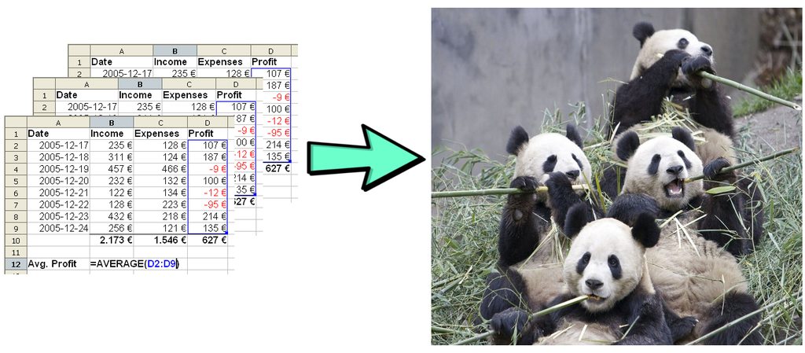

```python
Graphical abstract
```

**ToC**

- Preamble
  - Motivation
  - Conceptual understanding
- Programming basics
  - Variable assignment
  - Assigning multiple values to variables
    - Lists
    - Dictionaries
    - Comparisons
- Using functions
  - How to get help
  - Packages
  - Data analysis with pandas
  - Subsetting data
- Data visualization
  - Plotting with pandas
  - Plotting with seaborn
- Resources to learn more

# Preamble

This is a brief tutorial for anyone who is interested in how Python can facilitate their data analyses. The tutorial is aimed at people who currently use a spreadsheet program as their primary data analyses tool, and that have no previous programming experience. If you want to code along, a simple way to install Python [is to follow these instructions](https://github.com/UofTCoders/studyGroup/blob/gh-pages/lessons/r-python-conda-setup.md), but I encourage you to just read through this tutorial on a conceptual level at first.

## Motivation

Spreadsheet software is great for viewing and entering small datasets and creating simple visualizations fast. However, it can be tricky to create publication-ready figures, automate reproducible analysis workflows, perform advanced calculations, and clean datasets robustly. Even when using a spreadsheet program to record data, it is often beneficial to pick up some basic programming skills to facilitate the analyses of that data.

## Conceptual understanding

Spreadsheet programs, such as MS Excel and Libre/OpenOffice, have their functionality sectioned into menus. In programming languages, all the functionality is accessed by typing the name of functions directly instead of finding the functions in the menu hierarchy. Initially this might seem intimidating and non-intuitive for people who are used to the menu-driven approach.

However, think of it as learning a new natural language. Initially, you will slowly string together sentences by looking up individual words in the dictionary. As you improve, you will only reference the dictionary occasionally since you already know most of the words. Practicing the language whenever you can, and receiving immediate feedback, is often the fastest way to learn. Sitting at home trying to learn every word in the dictionary before engaging in conversation, is destined to kill the joy of learning any language, natural or formal.

In my experience, learning programming is similar to learning a foreign language, and you will often learn the most from just trying to do something and receiving feedback from the computer! When there is something you can't wrap you head around, or if you are actively trying to find a new way of expressing a thought, then look it up, just as you would with a natural language.

# Programming basics

Just like in spreadsheet software, the basic installation of Python includes fundamental math operations, e.g. adding numbers together:

```python
4 + 4
```

```
8
```

## Variable assignment

It is possible to assign values to variables:

```python
a = 5
a * 2
```

```
10
```

```python
my_variable_name = 4
a - my_variable_name
```

```
1
```

Variables can also hold more data types than just numbers, for example a sequence of characters surrounded by single or double quotation marks (called a *string*). In Python, it is intuitive to append string by adding them together:

```python
b = 'Hello'
c = 'universe'
b + c
```

```
'Hellouniverse'
```

A space can be added to separate the words:

```python
b + ' ' + c
```

```
'Hello universe'
```

## Assigning multiple values to variables

### Lists

Variables can also store more than one value, for example in a list of values:

```python
list_of_things = [1, 55, 'Hi']
list_of_things
```

```
[1, 55, 'Hi']
```

I can index the list to access a specific item. Note that numbering in Python starts at 0, so the third item `'Hi'`, has index 2.

```python
list_of_things[2]
```

```
'Hi'
```

### Dictionaries

In a dictionary, *values* are paired with names, called *keys*. These are not stored in any specific order, and are therefore accessed by the key name rather than a number.

```python
fruit_colors = {'tangerine':'organge', 'banana':'yellow', 'apple':['green', 'red']}
fruit_colors['banana']
```

```
'yellow'
```

```python
fruit_colors['apple']
```

```
['green', 'red']
```

## Comparisons

Python can compare values and assess whether the expression is true or false.

```python
1 == 1
```

```
True
```

```python
1 == 0
```

```
False
```

```python
1 > 0
```

```
True
```

```python
'hey' == 'Hey'
```

```
False
```

```python
'hey' == 'hey'
```

```
True
```

```python
a >= 2 * 2
```

```
True
```

When we start working with spreadsheet-like data, we will see that these comparisons are really useful to extract subsets of data, for example observations from a certain time period.

# Using functions

To access additional functionality in a spreadsheet program, you need to click the menu and select the tool you want to use. All charts are in one menu, text layout tools in another, data analyses tools in a third, and so on. Programming languages such as Python have so many tools and functions so that they would not fit in a menu. Instead of clicking `File -> Open` and chose the file, you would type something similar to `file.open('<filename>')` in a programming language. Don't worry if you forget the exact expression, it is often enough to just type the few first letters and then hit `Tab`, to show the available options, more on that later.

## Packages

Since there are so many esoteric tools and functions available in Python, it is unnecessary to include all of them with the basics that are loaded by default when you start the programming language (it would be as if your new phone came with every single app preinstalled). Instead, more advanced functionality is grouped into separate packages, which can be accessed by typing `import <package_name>` in Python. You can think of this as that you are telling the program which menu items you want to use (similar to how Excel hides the `Developer menu` by default since most people rarely use it and you need activate it in the settings if you want to access its functionality). Some packages needs to be downloaded before they can be used, just like downloading an addon to a browser or mobile phone.

Just like in spreadsheet software menus, there are lots of different tools within each Python package. For example, if I want to use numerical Python functions, I can import the **num**erical **py**thon module, `numpy`. I can then access any function by writing `numpy.<function_name>`.

```python
import numpy

numpy.mean([1, 2, 3, 4, 5])
```

```
3.0
```

## How to get help

Once you start out using Python, you don't know what functions are availble within each package. Luckily, in the Jupyter Notebook, you can type `numpy.``Tab` (that is numpy + period + tab-key) and a small menu will pop up that shows you all the available functions in that module. This is analogous to clicking a 'numpy-menu' and then going through the list of functions. As I mentioned earlier, there are plenty of available functions and it can be helpful to filter the menu by typing the initial letters of the function name.

To write this tutorial, I am using a software called Jupyter Notebook, and I took a screenshot of how the tab-completion appears in the notebook. Below I use the `Image` function from the `IPython.display` package to display this screenshot.

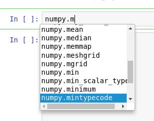

```python
from IPython.display import Image
Image('./tab-completion.png')
```

To get more info on the function you want to use, you can type out the full name and then press `Shift + Tab` once to bring up a help dialogue and again to expand that dialogue. Below I am displaying a screenshot for how this looks in the `numpy.mean` function. We can see that to use this function, we need to supply it with the argument `a`, which should be 'array-like'. An array is essentially just a sequence of numbers. In our previous example, we numbers enclosed in brackets `[]`, which in Python means that these numbers are in a list, which is a sequence of number just like an array.

We could also have defined `a` as a tuple: `(1, 2, 3, 4, 5)`, or the specific numpy array format: `numpy.array([1, 2, 3, 4, 5])`. For now, it is not important to know all the differences between these formats, and I am mainly including them so you get a better understanding of what it means for something to be 'array-like'.

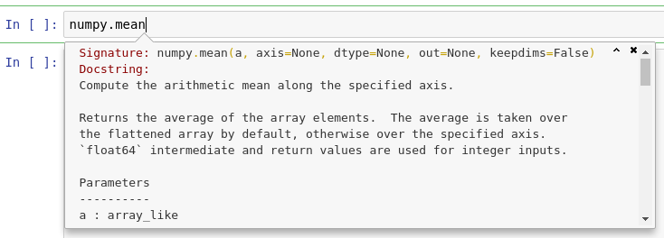

```python
Image('./shift-tab-help.png')
```

If you need a more extensive help dialog, you can click `Shift + Tab` four times or just type `?numpy.mean`.

When you start getting familiar with typing function names, you will notice that this is often faster than looking for functions in menus. It is similar to getting fluent in a language. I know what English words I want to type right now, and it is much easier for me to type them out, than to select each one from a menu. However, sometimes I forget and it is useful to get some hints as described above.

It is common to give packages nicknames, so that it is faster to type. This is not necessary, but can save some work in long files and make code less verbose so that it is easier to read:

```python
import numpy as np

np.std([1, 2, 3, 4, 5])
```

```
1.4142135623730951
```

# Data analysis with pandas

The Python package that is most commonly used to work with spreadsheet-like data is called `pandas`, the name is derived from "panel data", an econometrics term for multidimensional structured data sets. Data are easily loaded into pandas from `.csv` or other spreadsheet formats. The format pandas uses to store this data is called a dataframe.

I do not have any good data set lying around, so I will load a public dataset from the web (you can view the data by pasting the url into your browser). I store my dataframe in a variable called `iris`, that I can use to access the data from now on.

```python
import pandas as pd
pd.options.display.max_rows = 10 # Shortens the output from cells

iris = pd.read_csv('https://raw.githubusercontent.com/mwaskom/seaborn-data/master/iris.csv')
```

To have a quick peak at the data, I can type `iris.head(<number_of_rows>)`. Notice that I do not have to use the `pd.`-syntax for this. `iris` is now a pandas dataframe, and all pandas dataframes have a number of built-in functions (called methods) that can be appended directly to the dataframe instead of by calling `pandas` separately.

```python
iris.head() # The default is to show 5 rows
```

|  | sepal_length | sepal_width | petal_length | petal_width | species |
| --- | --- | --- | --- | --- | --- |
| 0 | 5.1 | 3.5 | 1.4 | 0.2 | setosa |
| 1 | 4.9 | 3.0 | 1.4 | 0.2 | setosa |
| 2 | 4.7 | 3.2 | 1.3 | 0.2 | setosa |
| 3 | 4.6 | 3.1 | 1.5 | 0.2 | setosa |
| 4 | 5.0 | 3.6 | 1.4 | 0.2 | setosa |

As you can see, the dataframe row numbering starts at 0, which might be confusing at first, but a standard in many programming languages and you get used to it quickly. I can easily find out how many rows and columns my data set has:

```python
iris.shape
```

```
(150, 5)
```

And the name of those five columns:

```python
iris.columns
```

```
Index(['sepal_length', 'sepal_width', 'petal_length', 'petal_width',
       'species'],
      dtype='object')
```

To select a column we can *index* the dataframe with the column name.

```python
iris['sepal_length']
```

```
0      5.1
1      4.9
2      4.7
3      4.6
4      5.0
      ...
145    6.7
146    6.3
147    6.5
148    6.2
149    5.9
Name: sepal_length, Length: 150, dtype: float64
```

The output is here rendered slightly differently from before, because when we are looking only at one column, it is no longer a data frame, but a *series*. The differences are not important for this lecture, so this is all you need to know about that for now.

We could now create a new column if we wanted:

```python
iris['sepal_length_x2'] = iris['sepal_length'] * 2
iris['sepal_length_x2']
```

```
0      10.2
1       9.8
2       9.4
3       9.2
4      10.0
       ...
145    13.4
146    12.6
147    13.0
148    12.4
149    11.8
Name: sepal_length_x2, Length: 150, dtype: float64
```

And delete that column again:

```python
iris = iris.drop('sepal_length_x2', axis=1)
```

There are some built-in methods that make it convenient to calculate common operation on dataframe columns.

```python
iris['sepal_length'].mean()
```

```
5.843333333333335
```

```python
iris['sepal_length'].median()
```

```
5.8
```

It is also possible to use these methods on all columns at the same time without having to type the same thing over and over again.

```python
iris.mean()
```

```
sepal_length    5.843333
sepal_width     3.057333
petal_length    3.758000
petal_width     1.199333
dtype: float64
```

Similarly, you can get a statistical summary of the data frame:

```python
iris.describe()
```

|  | sepal_length | sepal_width | petal_length | petal_width |
| --- | --- | --- | --- | --- |
| count | 150.000000 | 150.000000 | 150.000000 | 150.000000 |
| mean | 5.843333 | 3.057333 | 3.758000 | 1.199333 |
| std | 0.828066 | 0.435866 | 1.765298 | 0.762238 |
| min | 4.300000 | 2.000000 | 1.000000 | 0.100000 |
| 25% | 5.100000 | 2.800000 | 1.600000 | 0.300000 |
| 50% | 5.800000 | 3.000000 | 4.350000 | 1.300000 |
| 75% | 6.400000 | 3.300000 | 5.100000 | 1.800000 |
| max | 7.900000 | 4.400000 | 6.900000 | 2.500000 |

## Subsetting data

A common task is to subset the data into only those observations that match a criteria. For example, we might be interest in only studying one specific species. First let's find out how many different species there are in our dataset:

```python
iris['species'].unique()
```

```
array(['setosa', 'versicolor', 'virginica'], dtype=object)
```

Let's arbitrarily choose *setosa* as the one to study! To select only observations from this species in the original dataframe, we index the dataframe with a comparison:

```python
iris['species'] == 'setosa'
```

```
0       True
1       True
2       True
3       True
4       True
       ...
145    False
146    False
147    False
148    False
149    False
Name: species, Length: 150, dtype: bool
```

```python
iris[iris['species'] == 'setosa']
```

|  | sepal_length | sepal_width | petal_length | petal_width | species |
| --- | --- | --- | --- | --- | --- |
| 0 | 5.1 | 3.5 | 1.4 | 0.2 | setosa |
| 1 | 4.9 | 3.0 | 1.4 | 0.2 | setosa |
| 2 | 4.7 | 3.2 | 1.3 | 0.2 | setosa |
| 3 | 4.6 | 3.1 | 1.5 | 0.2 | setosa |
| 4 | 5.0 | 3.6 | 1.4 | 0.2 | setosa |
| ... | ... | ... | ... | ... | ... |
| 45 | 4.8 | 3.0 | 1.4 | 0.3 | setosa |
| 46 | 5.1 | 3.8 | 1.6 | 0.2 | setosa |
| 47 | 4.6 | 3.2 | 1.4 | 0.2 | setosa |
| 48 | 5.3 | 3.7 | 1.5 | 0.2 | setosa |
| 49 | 5.0 | 3.3 | 1.4 | 0.2 | setosa |

50 rows × 5 columns

Now we can easily perform computation on this subset of the data:

```python
iris[iris['species'] == 'setosa'].mean()
```

```
sepal_length    5.006
sepal_width     3.428
petal_length    1.462
petal_width     0.246
dtype: float64
```

```python
# The below calculates the mean for each row, but that is not very valuable on this data set
# iris[iris['species'] == 'setosa'].mean(axis=1)
```

We could also compare all groups within the data against each other, by using the split-apply-combine workflow. This splits data into groups, applies an operation on each group, and then combines the results into a table for display.

```python
iris.groupby('species').mean()
```

| species | sepal_length | sepal_width | petal_length | petal_width |
| --- | --- | --- | --- | --- |
| setosa | 5.006 | 3.428 | 1.462 | 0.246 |
| versicolor | 5.936 | 2.770 | 4.260 | 1.326 |
| virginica | 6.588 | 2.974 | 5.552 | 2.026 |

We can also easily count the number of observations in each group:

```python
iris.groupby('species').size()
```

```
species
setosa        50
versicolor    50
virginica     50
dtype: int64
```

## Data visualization

We can see that there are clear differences between species, but they might be even clearer if we display them graphically in a chart.

### Plotting with pandas

Pandas interfaces with one of Python's most powerful data visualization libraries, `matplotlib`, to enable simple visualizations at minimal effort.

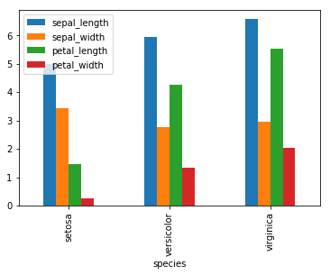

```python
# Prevent plots from popping up in a new window
%matplotlib inline

species_comparison = iris.groupby('species').mean() # Assign to a variable
species_comparison.plot(kind='bar')
```

Depending on what you are interesting in showing, it could be useful to have the species as the different colors and the columns along the x-axis. We can easily achieve this by transposing (`.T`) our data frame.

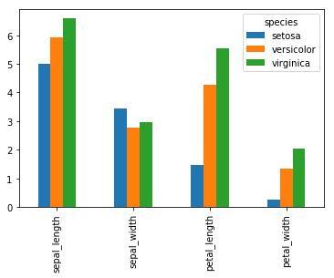

```python
species_comparison.T.plot(kind='bar')
```